# easy geom recipes

## Step 3a: define geom_* function

- define the stat and geom for your layer

```r
geom_label_row_number <- function(mapping = NULL, data = NULL,
                           position = "identity", na.rm = FALSE,
                           show.legend = NA,
                           inherit.aes = TRUE, ...) {
  ggplot2::layer(
    stat = StatRownumber, # proto object from Step 2
    geom = ggplot2::GeomLabel, # inherit other behavior
    data = data,
    mapping = mapping,
    position = position,
    show.legend = show.legend,
    inherit.aes = inherit.aes,
    params = list(na.rm = na.rm, ...)
  )
}
```

## Step 3b: Enjoy! Use your function

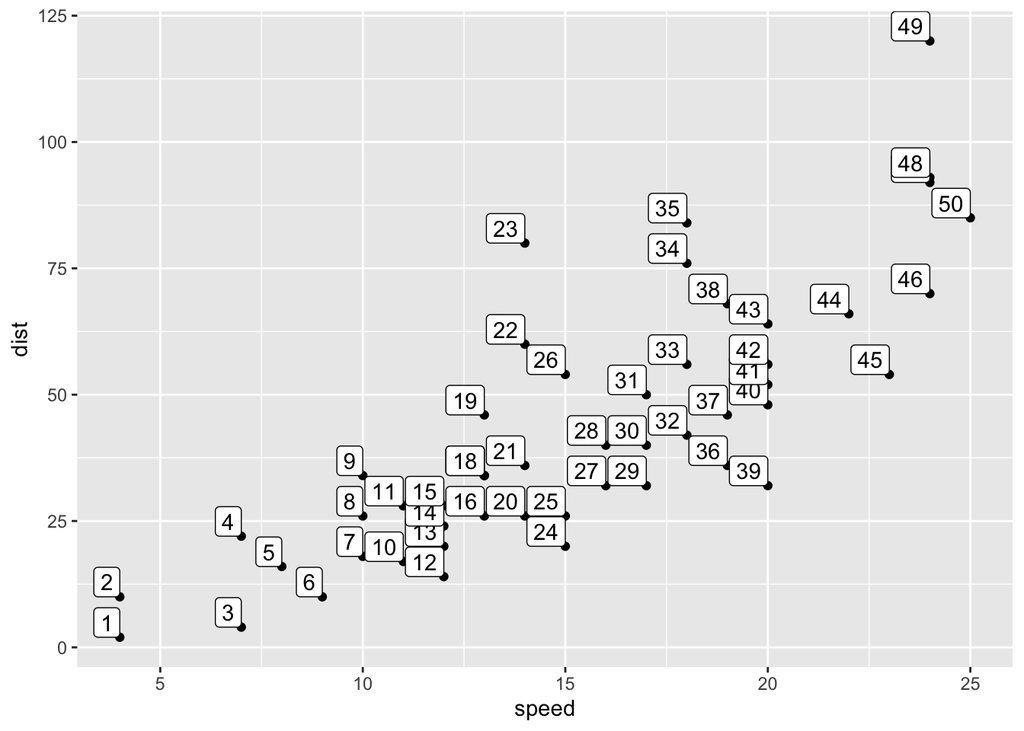

```r
cars |>
  ggplot() +
  aes(x = speed, y = dist) +
  geom_point() +
  geom_label_row_number(hjust = 1,
                        vjust = 0) # function in action
```

### And check out conditionality!

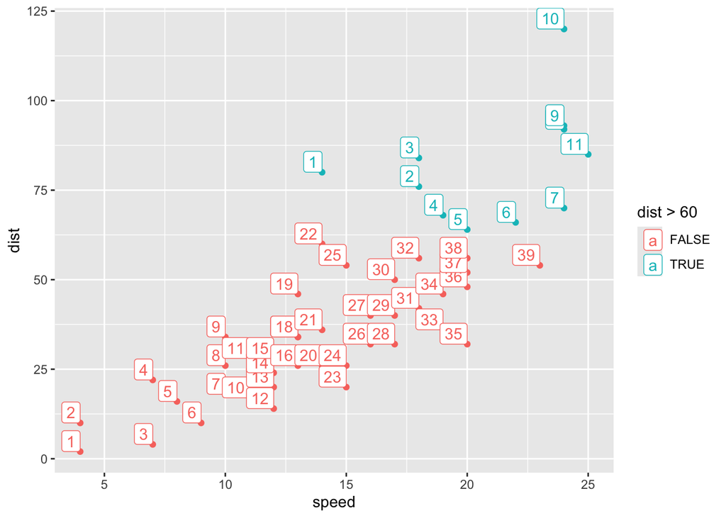

```r
last_plot() +
  aes(color = dist > 60) # Computation is within group
```

# Task #B: create `geom_text_coordinates()`

Using recipe #2 as a reference, can you create the function `geom_text_coordinates()`.

–

- geom should label point with its coordinates ‘(x, y)’
- geom should have behavior of geom_text (not geom_label)

Hint:

```r
paste0("(", 1, ", ", 3.5, ")")
```

```
## [1] "(1, 3.5)"
```

```r
# step 0: use base ggplot2

# step 1: write your compute_group function (and test)

# step 2: write ggproto with compute_group as an input

# step 3: write your geom_*() function with ggproto as an input

# step 4: enjoy!
```

# Example recipe #C: `geom_point_lm_fitted()`

## Step 0: use base ggplot2 to get the job done

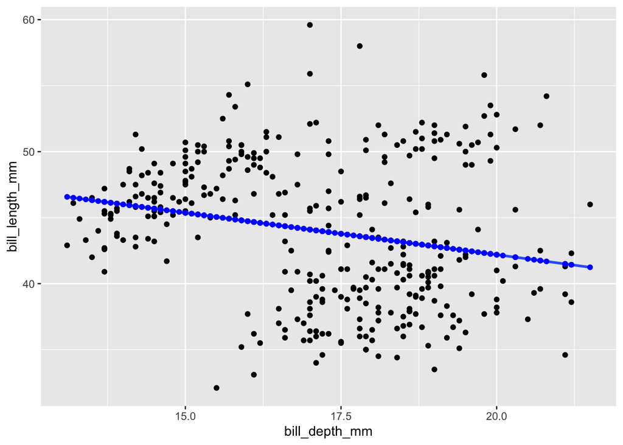

```r
model <- lm(formula = bill_length_mm ~ bill_depth_mm,
            data = penguins)

penguins_w_fitted <- penguins |>
  mutate(fitted = model$fitted.values)


penguins |>
  ggplot() +
  aes(x = bill_depth_mm, y = bill_length_mm) +
  geom_point() +
  geom_smooth(method = "lm", se = F) +
  geom_point(data = penguins_w_fitted,
             aes(y = fitted),
             color = "blue")
```

## Step 1a: write compute function

```r
compute_group_lm_fitted <- function(data, scales){
  model<-lm(formula= y ~ x, data = data)
  data |>
    mutate(y = model$fitted.values)
}
```

## Step 1b. test out the function

```r
penguins |>
  # select to explicitly state the x and y inputs
  select(x = bill_depth_mm, y = bill_length_mm)|>
  compute_group_lm_fitted()
```

```
## # A tibble: 333 × 2
##        x     y
##    <dbl> <dbl>
##  1  18.7  43.0
##  2  17.4  43.8
##  3  18    43.5
##  4  19.3  42.6
##  5  20.6  41.8
##  6  17.8  43.6
##  7  19.6  42.4
##  8  17.6  43.7
##  9  21.2  41.4
## 10  21.1  41.5
## # ℹ 323 more rows
```

## Step 2a: define new Stat

```r
StatLmFitted <-ggplot2::ggproto(`_class` = "StatLmFitted",
                               `_inherit` = ggplot2::Stat,
                               required_aes = c("x", "y"),
                               compute_group = compute_group_lm_fitted)
```

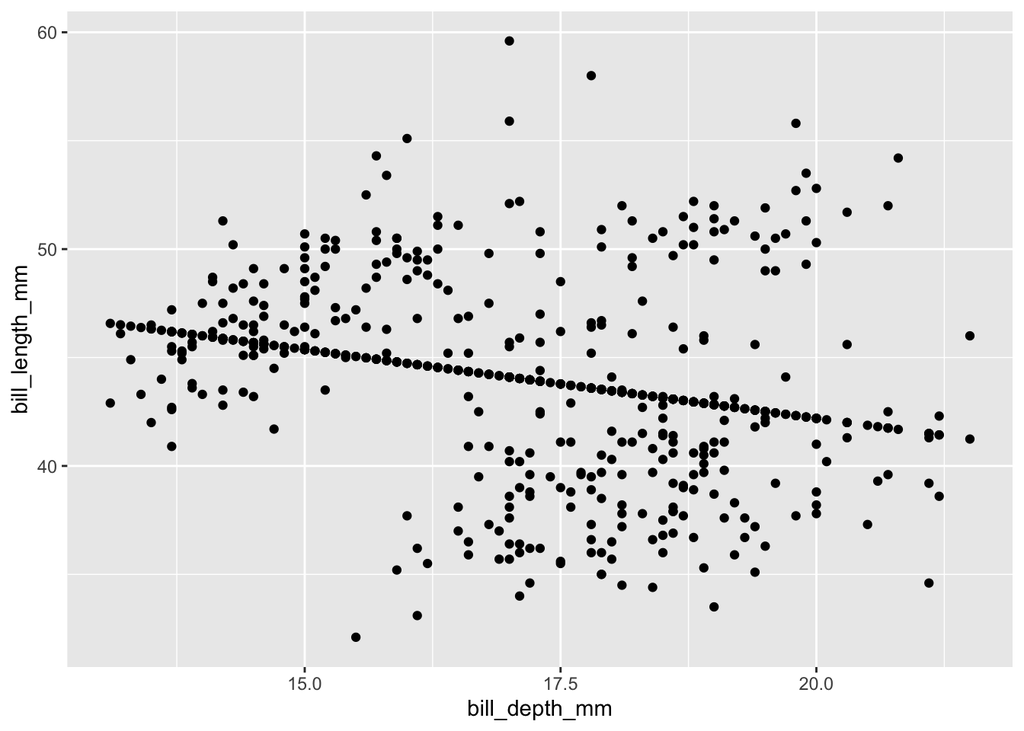

```r
penguins |>
  ggplot() +
  aes(x = bill_depth_mm, y = bill_length_mm) +
  geom_point() +
  layer(geom = GeomPoint,
        stat = StatLmFitted,
        position = "identity")
```

## Step 3a: define geom_* function

```r
geom_point_lm_fitted <- function(mapping = NULL, data = NULL,
                           position = "identity", na.rm = FALSE,
                           show.legend = NA,
                           inherit.aes = TRUE, ...) {
  ggplot2::layer(
    stat = StatLmFitted, # proto object from step 2
    geom = ggplot2::GeomPoint, # inherit other behavior
    data = data,
    mapping = mapping,
    position = position,
    show.legend = show.legend,
    inherit.aes = inherit.aes,
    params = list(na.rm = na.rm, ...)
  )
}
```

## Step 3b: Enjoy! Use your function

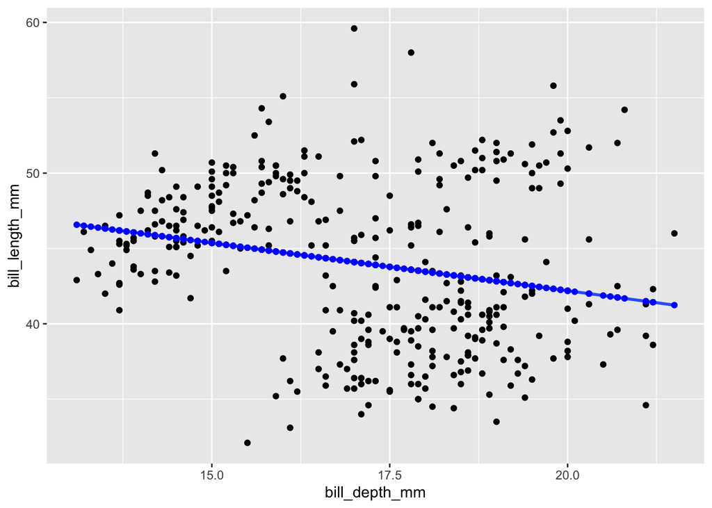

```r
penguins |>
  ggplot() +
  aes(x = bill_depth_mm, y = bill_length_mm) +
  geom_point() +
  geom_smooth(method="lm", se= F)+
  geom_point_lm_fitted(color="blue")
```

### And check out conditionality

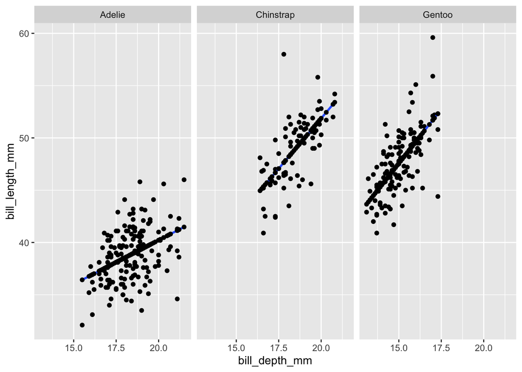

```r
penguins |>
  ggplot() +
  aes(x = bill_depth_mm, y = bill_length_mm) +
  geom_point() +
  geom_smooth(method="lm", se= F) +
  geom_point_lm_fitted() +
  facet_wrap(facets = vars(species))
```

# Task #C create `geom_segment_lm_residuals()`

Create the function `geom_segment_lm_residuals()`.

### Hint: consider what aesthetics are required for segments. We’ll give you Step 0 this time…

## Step 0: use base ggplot2 to get the job done

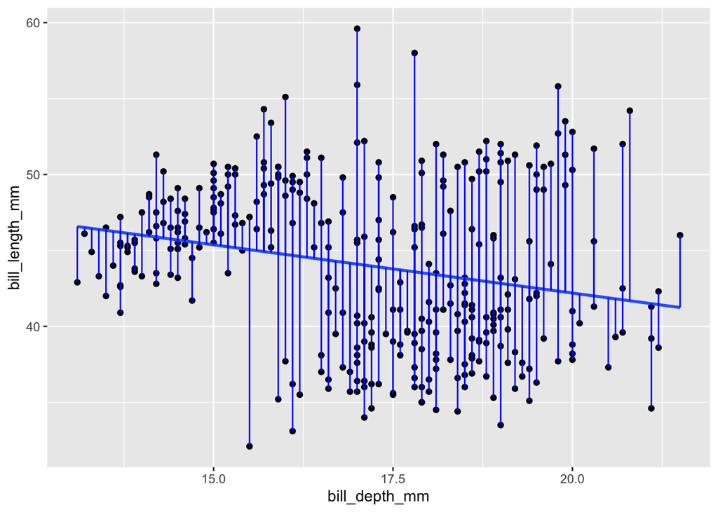

```r
# step 0: use base ggplot2
model <- lm(formula = bill_length_mm ~ bill_depth_mm,
            data = penguins)

penguins_w_fitted <- penguins |>
  mutate(fitted = model$fitted.values)

penguins |>
  ggplot() +
  aes(x = bill_depth_mm, y = bill_length_mm) +
  geom_point() +
  geom_smooth(method = "lm", se = F) +
  geom_segment(data = penguins_w_fitted,
             aes(yend = fitted, xend = bill_depth_mm),
             color = "blue")
```

```r
# step 1: write your compute_group function (and test)

# step 2: write ggproto with compute_group as an input

# step 3: write your geom_*() function with ggproto as an input

# step 4: enjoy!
```

Not interested in writing your own geoms?

Check out some ready-to-go geoms that might be of interest in the ggxmean package… or other extension packages.

Interested in working a bit more with geoms and making them available to more folks, but not interested in writing your own package?

Join in on the development and validation of the ggxmean package for statistical educators and everyday analysis!